# netCDFs in Python

## netCDF: Network Common Data Form

- Self describing
- Sharable
- Scalable
- Appendable

Uses:

- Climate model output
- Satalite products
- Meteorological/hydorlogical forecasts
- Reanalysis products
- Data with high dimension or spatiotemporal grids

## Python tools

- iris
- xarray
- others such as netcdf4, cf, geopandas

### xarray and iris

iris:

- metoffice
- specific (netCDF, GRIB, PP)
- rigorously cf compliant

xarray:

- a more generic data structure (hd5, json etc...)
- isn't strict on cf compliance
- based on pandas

## The cube

[figure not shown]

## Contents of a cube

- The data of any number of dimensions
- The dimensional coordinates
- Any auxillary coordinates
- Metadata

## Dimensional coordinates

Coords that describe one dimension/axis of the data:

- latitude, time, ensemble number etc
- Are fully descriptive (have units and abide by CF conventions)

## Auxillary coordinates

Coords which aren't necessary but may be useful:

- Day of the year
- A coordinate factory: a way of building a coord from an existing coord e.g. hybrid height

# Main pacakges

```python
import iris           # conda install -c conda-forge iris
import xarray as xr   # conda install -c anaconda xarray
```

```python
file = 'test.nc'
cube = iris.load_cube(file)
```

```python
type(cube)
```

```
iris.cube.Cube
```

```python
cube
```

| Air Temperature (K) | time | air_pressure | latitude | longitude |
| --- | --- | --- | --- | --- |
| Shape | 24 | 32 | 73 | 96 |
| Dimension coordinates |  |  |  |  |
| time | x | - | - | - |
| air_pressure | - | x | - | - |
| latitude | - | - | x | - |
| longitude | - | - | - | x |
| Auxiliary coordinates |  |  |  |  |
| year | x | - | - | - |
| Attributes |  |  |  |  |
| Conventions | CF-1.7 |  |  |  |
| STASH | m01s16i004 |  |  |  |
| associated_files | baseURL: http://www.met.reading.ac.uk/ccmi/ gridspecFile: gridspec_atm... |  |  |  |
| branch_time | 0.0 |  |  |  |
| comment |  |  |  |  |
| contact | N. Luke Abraham +44 1223 7 48899 |  |  |  |
| conversion_factor | 1 |  |  |  |
| experiment | Projection |  |  |  |
| experiment_id | refC1SD |  |  |  |
| forcing | N/A |  |  |  |
| frequency | mon |  |  |  |
| history | Model jobid = xinxe. Created using Iris version 1.9.2. SSTs and Sea-Ice... |  |  |  |
| initialization_description |  |  |  |  |
| initialization_method | 1 |  |  |  |
| institute_id | U-CAMBRIDGE |  |  |  |
| institution | Department of Chemistry, University of Cambridge, Cambridge, UK. |  |  |  |
| iris_history | Cube was interpolated by model_interpolate.py on 2021-02-12 17:03 |  |  |  |
| model_id | UMUKCA-UCAM |  |  |  |
| modeling_realm | atmos |  |  |  |
| parent_experiment_id | N/A |  |  |  |
| parent_experiment_rip | N/A |  |  |  |
| physics_description |  |  |  |  |
| physics_version | 1 |  |  |  |
| product | output |  |  |  |
| project_id | CCMI1 |  |  |  |
| realization | 1 |  |  |  |
| references | Stratospheric chemistry expanded from Morgenstern, O., Braesicke, P., O'Connor,... |  |  |  |
| source | UMUKCA-UCAM 2013 atmosphere: MetUM (MetUM vn7.3 HadGEM3-A r2.0, N48L60)... |  |  |  |
| table_id | Table monthly (31 October 2014) |  |  |  |
| title | UMUKCA-UCAM model output prepared for CCMI1 Projection |  |  |  |
| um_version | 7.3 |  |  |  |
| Cell methods |  |  |  |  |
| mean | time |  |  |  |

### Where's the data?

```python
data = cube.data
```

```python
data.shape
```

```
(24, 32, 73, 96)
```

```python
type(data)
```

```
numpy.ma.core.MaskedArray
```

### What about the coords?

```
cube.coords()
cube.dim_coords
cube.aux_coords
```

```python
cube.coord('air_pressure')
```

```
DimCoord(array([908.507131 , 787.564754 , 682.72248  , 591.837029 , 513.050441 ,
       444.752089 , 385.545757 , 334.221096 , 289.728882 , 251.159564 ,
       217.724676 , 188.74071  , 163.61515  , 141.834357 , 122.95307  ,
       106.585299 ,  92.3964402,  80.096432 ,  69.4338267,  60.1906499,
        52.1779442,  45.2319067,  39.2105402,  33.9907508,  29.4658306,
        25.5432774,  22.1429026,  19.1951929,  16.6398885,  14.4247516,
        12.5044984,  10.8398733]), standard_name='air_pressure', units=Unit('Pa'), var_name='air_pressure')
```

```
cube.coord('air_pressure').points
cube.coord('air_pressure').bounds
cube.coord('air_pressure').units
```

### Time

```python
time_coord = cube.coord('time')
```

```python
print(time_coord[:3])
```

```
DimCoord([1979-01-16 12:00:00, 1979-02-15 00:00:00, 1979-03-16 12:00:00], bounds=[[1979-01-01 00:00:00, 1979-02-01 00:00:00],
       [1979-02-01 00:00:00, 1979-03-01 00:00:00],
       [1979-03-01 00:00:00, 1979-04-01 00:00:00]], standard_name='time', calendar='gregorian', var_name='time')
```

```python
time_coord[:3]
```

```
DimCoord(array([6955.5, 6985. , 7014.5]), bounds=array([[6940., 6971.],
       [6971., 6999.],
       [6999., 7030.]]), standard_name='time', units=Unit('days since 1960-01-01', calendar='gregorian'), var_name='time')
```

### Indexing cubes, data and coords

Most objects and datatypes in iris can be indexed as you would in numpy. Each time returning a iris cube

```
cube[:10]
cube[0, :, :, -5:]
cube[::12]
time_coord[:15]
```

```python
cube[0,0,0,0]
```

| Air Temperature (K) | (scalar cube) |
| --- | --- |
| Scalar coordinates |  |
| air_pressure | 908.507131 Pa |
| latitude | -90.0 degrees, bound=(-90.0, -88.75) degrees |
| longitude | 0.0 degrees, bound=(-1.875, 1.875) degrees |
| time | 1979-01-16 12:00:00, bound=(1979-01-01 00:00:00, 1979-02-01 00:00:00) |
| year | 1979 |
| Cell methods |  |
| mean | time |

### Selecting data

```python
lat_con = iris.Constraint(latitude=lambda cell: 60 <= cell <= 90)
cube.extract(constraint=lat_con);
```

```python
lon_con = iris.Constraint(longitude=0)
cube.extract(constraint=lat_con & lon_con)
```

| Air Temperature (K) | time | air_pressure | latitude |
| --- | --- | --- | --- |
| Shape | 24 | 32 | 13 |
| Dimension coordinates |  |  |  |
| time | x | - | - |
| air_pressure | - | x | - |
| latitude | - | - | x |
| Auxiliary coordinates |  |  |  |
| year | x | - | - |
| Scalar coordinates |  |  |  |
| longitude | 0.0 degrees, bound=(-1.875, 1.875) degrees |  |  |
| Cell methods |  |  |  |
| mean | time |  |  |

For time

```python
year_con = iris.Constraint(time=lambda cell: cell.point.year == 1980)
```

```python
from iris.time import PartialDateTime

dt1 = PartialDateTime(year=1980, month=5, day=1)
time_con = iris.Constraint(time=lambda cell: cell.point < dt1)
cube.extract(constraint=time_con)
```

| Air Temperature (K) | time | air_pressure | latitude | longitude |
| --- | --- | --- | --- | --- |
| Shape | 16 | 32 | 73 | 96 |
| Dimension coordinates |  |  |  |  |
| time | x | - | - | - |
| air_pressure | - | x | - | - |
| latitude | - | - | x | - |
| longitude | - | - | - | x |
| Auxiliary coordinates |  |  |  |  |
| year | x | - | - | - |
| Cell methods |  |  |  |  |
| mean | time |  |  |  |

## Similarity with xarray

```python
ds = xr.open_dataset(file)
```

```python
ds;
```

[figure not shown]

```python
da = ds['ta']
```

```python
da;
```

[figure not shown]

Getting data

```python
data = da.data
```

```python
type(data)
```

```
numpy.ndarray
```

Coords

```python
time_coord = da.time
time_coord = da['time']
```

```python
time_coord[:3]
```

```
<xarray.DataArray 'time' (time: 3)>
array(['1979-01-16T12:00:00.000000000', '1979-02-15T00:00:00.000000000',
       '1979-03-16T12:00:00.000000000'], dtype='datetime64[ns]')
Coordinates:
  * time     (time) datetime64[ns] 1979-01-16T12:00:00 ... 1979-03-16T12:00:00
    year     (time) int64 ...
Attributes:
    axis:           T
    bounds:         time_bnds
    standard_name:  time
```

## Indexing

```
da[:10]
da[0, :, :, -5:]
da[6::12]
time_coord[:15]
```

Physically selecting

```
da.loc[{'lat': slice(40,60)}]
da.sel(lat=slice(40,60))

da.loc[{'lat': [60,80]}]
da.sel(lat=[60, 80])

da.sel(time=slice("1980-01-01", "1980-05-01"))
```

### Interoperability between xarray, iris and pandas

```python
cube_new = da.to_iris()
da_new = xr.DataArray.from_iris(cube)
```

```python
da[:2,0,0,0].to_dataframe()
```

| time | air_pressure | lat | lon | year | ta |
| --- | --- | --- | --- | --- | --- |
| 1979-01-16 12:00:00 | 908.507131 | -90.0 | 0.0 | 1979 | 247.154739 |
| 1979-02-15 00:00:00 | 908.507131 | -90.0 | 0.0 | 1979 | 240.014883 |

```python
import iris.pandas
cube.remove_coord('year')
iris.pandas.as_data_frame(cube[0,0]).head() # Only works in 2D
```

|  | 0.00 | 3.75 | 7.50 | 11.25 | 15.00 | 18.75 | 22.50 | 26.25 | 30.00 | 33.75 | ... | 322.50 | 326.25 | 330.00 | 333.75 | 337.50 | 341.25 | 345.00 | 348.75 | 352.50 | 356.25 |
| --- | --- | --- | --- | --- | --- | --- | --- | --- | --- | --- | --- | --- | --- | --- | --- | --- | --- | --- | --- | --- | --- |
| -90.0 | 247.154739 | 247.154739 | 247.154739 | 247.154739 | 247.154739 | 247.154739 | 247.154739 | 247.154739 | 247.154739 | 247.154739 | ... | 247.154739 | 247.154739 | 247.154739 | 247.154739 | 247.154739 | 247.154739 | 247.154739 | 247.154739 | 247.154739 | 247.154739 |
| -87.5 | 247.188339 | 247.191299 | 247.194168 | 247.196945 | 247.199615 | 247.202164 | 247.204559 | 247.206787 | 247.208786 | 247.210571 | ... | 247.159866 | 247.162247 | 247.164780 | 247.167450 | 247.170258 | 247.173157 | 247.176147 | 247.179184 | 247.182251 | 247.185303 |
| -85.0 | 247.215836 | 247.226059 | 247.236191 | 247.246277 | 247.256180 | 247.265808 | 247.275024 | 247.283661 | 247.291519 | 247.298370 | ... | 247.130844 | 247.136490 | 247.142853 | 247.149872 | 247.157425 | 247.165710 | 247.174881 | 247.184769 | 247.195053 | 247.205460 |
| -82.5 | 247.299774 | 247.316254 | 247.331131 | 247.345078 | 247.358429 | 247.371002 | 247.382675 | 247.393234 | 247.402252 | 247.409454 | ... | 247.093994 | 247.113754 | 247.134689 | 247.156189 | 247.177383 | 247.198166 | 247.219177 | 247.240524 | 247.261505 | 247.281433 |
| -80.0 | 247.379120 | 247.390762 | 247.399826 | 247.407745 | 247.415375 | 247.422424 | 247.428558 | 247.433197 | 247.435425 | 247.435028 | ... | 247.107117 | 247.142532 | 247.178497 | 247.213120 | 247.244781 | 247.273331 | 247.299561 | 247.323822 | 247.345566 | 247.364075 |

5 rows × 96 columns

```
iris.pandas.as_cube(df)
```

## Basic plotting

```python
import iris.quickplot as qplt
```

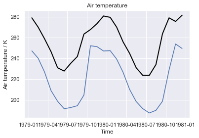

```python
qplt.plot(cube[:, 0,0,0])
qplt.plot(cube[:, 10,10,10], lw=2, color='black');
```

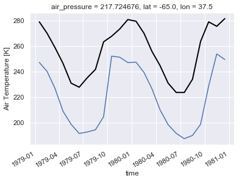

```python
da[:,0,0,0].plot()
da[:,10,10,10].plot(lw=2, color='black');
```

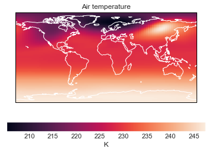

```python
qplt.pcolormesh(cube[0,0,:,:])
plt.gca().coastlines(color='white');
```

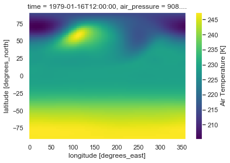

```python
da[0,0,:,:].plot.pcolormesh();
```

## Some useful operations

Some iris, some xarray but most (if not all) operations work in both

## Basic arithmetic

```python
cube[0] + cube[1];
```

```python
da[0] / da[1];
```

```python
da += 2
```

```python
cube[0] ** 2
```

| Unknown (K2) | air_pressure | latitude | longitude |
| --- | --- | --- | --- |
| Shape | 32 | 73 | 96 |
| Dimension coordinates |  |  |  |
| air_pressure | x | - | - |
| latitude | - | x | - |
| longitude | - | - | x |
| Scalar coordinates |  |  |  |
| time | 1979-01-16 12:00:00, bound=(1979-01-01 00:00:00, 1979-02-01 00:00:00) |  |  |

```python
cube.collapsed('longitude', iris.analysis.MEAN);
```

```python
da.mean('lon');
```

## Numpy works with xarray

```python
np.log10(da);
```

```python
np.log10(da).units
```

```
---------------------------------------------------------------------------
AttributeError                            Traceback (most recent call last)
<ipython-input-44-39858564e9ce> in <module>
----> 1 np.log10(da).units

~/anaconda3/lib/python3.6/site-packages/xarray/core/common.py in __getattr__(self, name)
    177                     return source[name]
    178         raise AttributeError("%r object has no attribute %r" %
--> 179                              (type(self).__name__, name))
    180
    181     def __setattr__(self, name, value):

AttributeError: 'DataArray' object has no attribute 'units'
```

```python
import iris.analysis.maths as ip
ip.log10(cube);
```

```python
ip.log10(cube).units
```

```
Unit('lg(re 1 K)')
```

### Temporal means

```python
import iris.coord_categorisation as cc

cc.add_season(cube, 'time')
```

```python
cube.coord('season')
```

```
AuxCoord(array(['djf', 'djf', 'mam', 'mam', 'mam', 'jja', 'jja', 'jja', 'son',
       'son', 'son', 'djf', 'djf', 'djf', 'mam', 'mam', 'mam', 'jja',
       'jja', 'jja', 'son', 'son', 'son', 'djf'], dtype='<U64'), standard_name=None, units=Unit('no_unit'), long_name='season')
```

```python
cube_season = cube.aggregated_by('season', iris.analysis.MEAN)
```

## Regridding/resampling

```python
cube_0 = cube[0,0]
```

```python
cube_regrid = cube_0.regrid(regrid_temp, iris.analysis.AreaWeighted())
```

```python
repr(cube_0)
```

```
"<iris 'Cube' of air_temperature / (K) (latitude: 73; longitude: 96)>"
```

```python
repr(cube_regrid)
```

```
"<iris 'Cube' of air_temperature / (K) (latitude: 180; longitude: 288)>"
```

## Unit conversion

```python
print(cube.coord('air_pressure').points[:2])
```

```
[908.507131 787.564754]
```

```python
cube.coord('air_pressure').units
```

```
Unit('Pa')
```

```python
cube.coord('air_pressure').convert_units('hPa')
```

```python
print(cube.coord('air_pressure').points[:2])
```

```
[9.08507131 7.87564754]
```

```python
cube.coord('air_pressure').units
```

```
Unit('hPa')
```

## Integrating into a ML workflow

```python
df = da.to_dataframe()
```

```python
type(df)
```

```
pandas.core.frame.DataFrame
```

```python
df.head()
```

| time | air_pressure | lat | lon | year | ta |
| --- | --- | --- | --- | --- | --- |
| 1979-01-16 12:00:00 | 908.507131 | -90.0 | 0.00 | 1979 | 249.154739 |
|  |  |  | 3.75 | 1979 | 249.154739 |
|  |  |  | 7.50 | 1979 | 249.154739 |
|  |  |  | 11.25 | 1979 | 249.154739 |
|  |  |  | 15.00 | 1979 | 249.154739 |

```
df.groupby(['year', 'lat', 'lon']).mean()

df.to_csv('file.csv')
df.to_json('file.json')
```

## Lazy loading

100GB of model data

```python
%timeit ens_cube = iris.load('/Users/amosm1/atmos-data/CESMLENS/*20C*.nc')
```

```
340 ms ± 48 ms per loop (mean ± std. dev. of 7 runs, 1 loop each)
```

```python
%timeit ens_cube.coord('member_id')
```

```
10.6 µs ± 120 ns per loop (mean ± std. dev. of 7 runs, 100000 loops each)
```

```python
ens_cube
```

| Reference Height Temperature (K) | member_id | time | latitude | longitude |
| --- | --- | --- | --- | --- |
| Shape | 7 | 1140 | 192 | 288 |
| Dimension coordinates |  |  |  |  |
| member_id | x | - | - | - |
| time | - | x | - | - |
| latitude | - | - | x | - |
| longitude | - | - | - | x |
| Cell methods |  |  |  |  |
| mean | time |  |  |  |

## Joining files

```python
concat_ds = xr.open_mfdataset('/Users/amosm1/atmos-data/Ozone/BDBP/v3.4_unpatched/NIWA-BS_CombinedTCO_V3.4_198*.nc')
```

```python
concat_da = concat_ds.tco
```

```python
type(concat_da)
```

```
xarray.core.dataarray.DataArray
```

```python
type(concat_da.data)
```

```
dask.array.core.Array
```

## Pangeo

- Focus moving towards cloud based infrastructure
- Pangeo is an environmemt including iris and xarray
- Using dask (and zarr and intake) the functions and code stay the same but you can distribute your computations and lazily compute on only the data you need

[figure not shown]

# Next python session (Sam Harrison):

# Raster data - geopandas/ rasterio/ folium

# 13:00 13th April